# 01_Comparing_regression_models

16/04/2020

- Introduction
- Comparing models using R<sup>2</sup>
- Comparing models using rmse
- Comparing regression models with `anova()`
- Using variable selection methods
- Conclusion

## Introduction

In the following sections, we will be using the `diamonds` data from `ggplot2` to compare two models derivable from this data set. The `diamonds` data set has 10 attributes and over 50,000 records.

```r
library(ggplot2)
data("diamonds")
```

```r
diamonds <- diamonds
str(diamonds)
```

```
## Classes 'tbl_df', 'tbl' and 'data.frame':    53940 obs. of  10 variables:
##  $ carat  : num  0.23 0.21 0.23 0.29 0.31 0.24 0.24 0.26 0.22 0.23 ...
##  $ cut    : Ord.factor w/ 5 levels "Fair"<"Good"<..: 5 4 2 4 2 3 3 3 1 3 ...
##  $ color  : Ord.factor w/ 7 levels "D"<"E"<"F"<"G"<..: 2 2 2 6 7 7 6 5 2 5 ...
##  $ clarity: Ord.factor w/ 8 levels "I1"<"SI2"<"SI1"<..: 2 3 5 4 2 6 7 3 4 5 ...
##  $ depth  : num  61.5 59.8 56.9 62.4 63.3 62.8 62.3 61.9 65.1 59.4 ...
##  $ table  : num  55 61 65 58 58 57 57 55 61 61 ...
##  $ price  : int  326 326 327 334 335 336 336 337 337 338 ...
##  $ x      : num  3.95 3.89 4.05 4.2 4.34 3.94 3.95 4.07 3.87 4 ...
##  $ y      : num  3.98 3.84 4.07 4.23 4.35 3.96 3.98 4.11 3.78 4.05 ...
##  $ z      : num  2.43 2.31 2.31 2.63 2.75 2.48 2.47 2.53 2.49 2.39 ...
```

We will use the `carat`, `clarity` and `color` attributes only to predict `price` in our examination of comparing two models. Naturally, more attributes can be used from this data set to derive better quality models. However, since the focus is on “comparing” models, and not finding the best model, these 3 attributes will suffice.

## Comparing models using R<sup>2</sup>

Though this is not always the case, a regression model with a higher R<sup>2</sup> value may be a better model. R<sup>2</sup> is defined as the amount of variation in the response variable explained by the model. In the case where all the points fall on the line and the sum of the squared of the residuals is zero, all of the variation in the response variable is explained by the model. Therefore R<sup>2</sup> is 1. Where none is explained, so that the mean value of the response variable is all there is, R<sup>2</sup> equates to zero.

Because R<sup>2</sup> will naturally increase in value with the addition of more predictors, it is often a better approach to use adjusted R<sup>2</sup> as a comparison indicator, since this accounts for the number of predictors present in the model.

Using the `lm` function, we examine our two models.

```r
diamonds.mod1 <- lm(price ~ carat, data = diamonds)
summary(diamonds.mod1)
```

```
##
## Call:
## lm(formula = price ~ carat, data = diamonds)
##
## Residuals:
##      Min       1Q   Median       3Q      Max
## -18585.3   -804.8    -18.9    537.4  12731.7
##
## Coefficients:
##             Estimate Std. Error t value Pr(>|t|)
## (Intercept) -2256.36      13.06  -172.8   <2e-16 ***
## carat        7756.43      14.07   551.4   <2e-16 ***
## ---
## Signif. codes:  0 '***' 0.001 '**' 0.01 '*' 0.05 '.' 0.1 ' ' 1
##
## Residual standard error: 1549 on 53938 degrees of freedom
## Multiple R-squared:  0.8493, Adjusted R-squared:  0.8493
## F-statistic: 3.041e+05 on 1 and 53938 DF,  p-value: < 2.2e-16
```

```r
diamonds.mod2 <- lm(price ~ carat + clarity + color, data = diamonds)
summary(diamonds.mod2)
```

```
##
## Call:
## lm(formula = price ~ carat + clarity + color, data = diamonds)
##
## Residuals:
##      Min       1Q   Median       3Q      Max
## -17310.9   -678.0   -192.2    473.0  10313.2
##
## Coefficients:
##             Estimate Std. Error  t value Pr(>|t|)
## (Intercept) -3506.64      12.89 -272.009  < 2e-16 ***
## carat        8856.23      12.10  731.857  < 2e-16 ***
## clarity.L    4417.66      30.63  144.218  < 2e-16 ***
## clarity.Q   -1939.31      28.88  -67.150  < 2e-16 ***
## clarity.C    1009.46      24.79   40.714  < 2e-16 ***
## clarity^4    -410.68      19.87  -20.663  < 2e-16 ***
## clarity^5     242.64      16.28   14.907  < 2e-16 ***
## clarity^6     -12.13      14.19   -0.855    0.393
## clarity^7     121.32      12.52    9.688  < 2e-16 ***
## color.L     -1916.89      17.92 -106.985  < 2e-16 ***
## color.Q      -629.34      16.31  -38.597  < 2e-16 ***
## color.C      -181.84      15.24  -11.931  < 2e-16 ***
## color^4        18.58      14.00    1.327    0.184
## color^5       -86.19      13.23   -6.517 7.25e-11 ***
## color^6       -56.21      12.03   -4.674 2.96e-06 ***
## ---
## Signif. codes:  0 '***' 0.001 '**' 0.01 '*' 0.05 '.' 0.1 ' ' 1
##
## Residual standard error: 1170 on 53925 degrees of freedom
## Multiple R-squared:  0.914,  Adjusted R-squared:  0.9139
## F-statistic: 4.092e+04 on 14 and 53925 DF,  p-value: < 2.2e-16
```

`diamonds.mod1` has a R<sup>2</sup> value of ~85%, while `diamonds.mod2` has a higher value of ~91%. The adjusted R<sup>2</sup> value of the latter model is also better, suggesting it is probably better suited for predicting the value of price than does the former. In intepreting the slope coefficient from `diamonds.mod1`, we say that a unit increase in `carat` value increases `price` by 7756. The output from the latter model is a little bit more convoluted. There is one numerical and two categorical independent variables. A unit increase in `carat` value increases `price` by 8856 after controlling for `clarity` and `color`. Similarly, each factor value of clarity or color increases price by their respective coefficients after controlling for all other variables.

Clearly, with more information, the second model is able to deliver a better prediction for `price` than the first.

It is widely accepted that R<sup>2</sup> is never enough as an indicator for assessing the fit of a model. An additional check which should follow is an examination of the residuals plot of the two models in order to compare how well they fit. A model’s residual plot can be easily assessed using the plot function in R. In this case, the plots still confirm the second model to be a slightly better fit than the first.

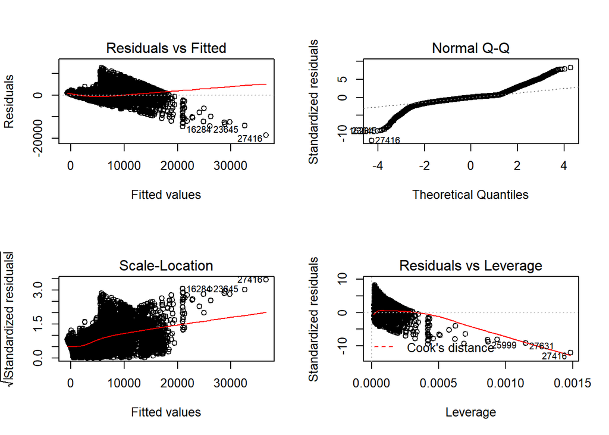

```r
par(mfrow=c(2,2))
plot(diamonds.mod1)
```

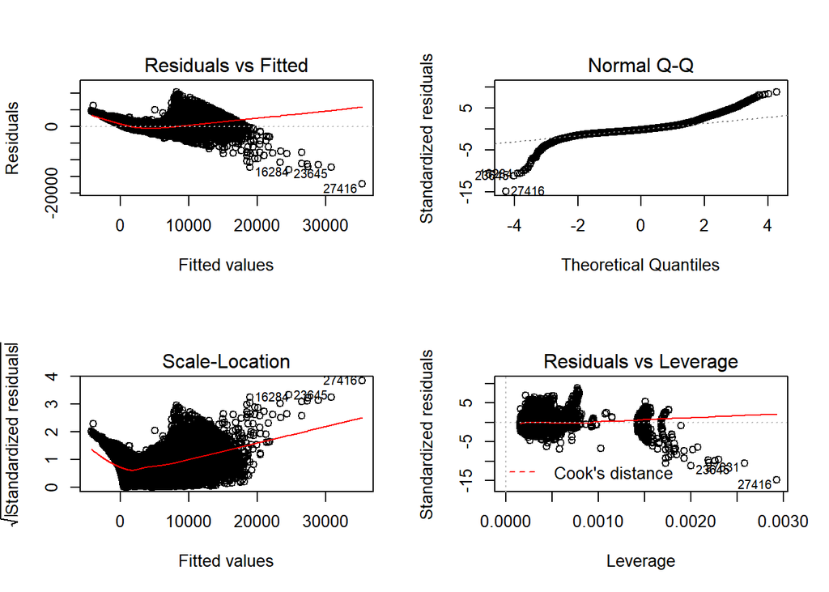

```r
par(mfrow=c(2,2))
plot(diamonds.mod2)
```

## Comparing models using `rmse`

Next, we examine using `rmse` to compare the results of two models. `rmse` is root-mean squared error and gives a spread of the actual dependent variable around the predicted value. Though closely related to R<sup>2</sup>, they are not exactly the same. While R<sup>2</sup> is the fraction of the total sum of squares explained by the model, `rmse` is the root mean squared of the errors, an absolute measure of fit. Lower values of `rmse` indicate a better fit.

Examining our previous two models, we can obtain the `rmse` by using the fitted values produced by the model and the actual values from the data set.

```r
library(broom)
diamonds.mod1.aug <- augment(diamonds.mod1)
head(diamonds.mod1.aug)
```

```
## # A tibble: 6 x 9
##   price carat .fitted .se.fit .resid      .hat .sigma     .cooksd .std.resid
##   <int> <dbl>   <dbl>   <dbl>  <dbl>     <dbl>  <dbl>       <dbl>      <dbl>
## 1   326 0.23  -472.     10.4    798. 0.0000452  1549. 0.00000600       0.516
## 2   326 0.21  -628.     10.6    954. 0.0000471  1549. 0.00000892       0.616
## 3   327 0.23  -472.     10.4    799. 0.0000452  1549. 0.00000602       0.516
## 4   334 0.290   -7.00    9.77   341. 0.0000398  1549. 0.000000966      0.220
## 5   335 0.31   148.      9.57   187. 0.0000382  1549. 0.000000278      0.121
## 6   336 0.24  -395.     10.3    731. 0.0000442  1549. 0.00000493       0.472
```

Using the `rmse` function from the `Metrics` library, we can compute the rmse of the first model.

```r
Metrics::rmse(diamonds$price, diamonds.mod1.aug$.fitted)
```

```
## [1] 1548.533
```

Alternatively, we could use the original formula to obtain the `rmse`.

```r
sqrt(sum((diamonds$price - diamonds.mod1.aug$.fitted)^2)/nrow(diamonds))
```

```
## [1] 1548.533
```

Similary, the second model produces a `rmse` of 1170, which is significantly lower than the result from the first model. This could suggest that the second model is indeed better than the first as we originally ascertained.

```r
diamonds.mod2.aug <- augment(diamonds.mod2)
Metrics::rmse(diamonds$price, diamonds.mod2.aug$.fitted)
```

```
## [1] 1170.186
```

## Comparing regression models with `anova()`

To compare the fits of two models, we could also use the `anova()` function with the regression objects as two separate arguments. If the resulting p-value is sufficiently low (usually less than 0.05), we could conclude that the more complex model is significantly better than the simpler model. Otherwise, it could mean that there is no significant difference between the two models.

```r
anova(diamonds.mod1, diamonds.mod2)
```

```
## Analysis of Variance Table
##
## Model 1: price ~ carat
## Model 2: price ~ carat + clarity + color
##   Res.Df        RSS Df  Sum of Sq    F    Pr(>F)
## 1  53938 1.2935e+11
## 2  53925 7.3862e+10 13 5.5484e+10 3116 < 2.2e-16 ***
## ---
## Signif. codes:  0 '***' 0.001 '**' 0.01 '*' 0.05 '.' 0.1 ' ' 1
```

The result shows that there is significant difference between the two models after adding those additional two terms, `clarity` and `color`. A F-test is carried out in the comparison of the two models. The resulting F-statistic lies beyond the rejection region and showing that the difference between the two models cannot be left to chance alone.

## Using variable selection methods

Another approach to selecting a good model in R, or at least confirming that one model offers better prediction than the other, is using a variable selection method which descends (or ascends) step-wise in its comparison of models. `stepAIC` from the `MASS` package offers a step-wise model selection process using the Akaike Information Criterion (AIC). The AIC is a technique for estimating the likelihood of a model to predict or estimate future values. A good model is one that has minimum AIC among all the other models. Therefore, using such step-wise comparison, a set of best predictor variables can be obtained from a combination of available predictor values.

```r
library(MASS)
null <- lm(price ~ 1, data = diamonds)
full <- lm(price ~ carat + clarity + color, data = diamonds)
stepF <- stepAIC(null, scope = list(lower = null, upper = full), direction = "forward", trace = TRUE)
```

```
## Start:  AIC=894477.9
## price ~ 1
##
##           Df  Sum of Sq        RSS    AIC
## + carat    1 7.2913e+11 1.2935e+11 792389
## + color    6 2.6849e+10 8.3162e+11 892776
## + clarity  7 2.3308e+10 8.3517e+11 893007
## <none>                  8.5847e+11 894478
##
## Step:  AIC=792389.4
## price ~ carat
##
##           Df  Sum of Sq        RSS    AIC
## + clarity  7 3.9082e+10 9.0264e+10 772998
## + color    6 1.2561e+10 1.1678e+11 786891
## <none>                  1.2935e+11 792389
##
## Step:  AIC=772998.5
## price ~ carat + clarity
##
##         Df  Sum of Sq        RSS    AIC
## + color  6 1.6402e+10 7.3862e+10 762193
## <none>                9.0264e+10 772998
##
## Step:  AIC=762193.4
## price ~ carat + clarity + color
```

Here, the result shows that the best AIC is achieved from the combination of `color`, `clarity` and `carat` as predictor variables.

## Conclusion

In addition to these described methods, there are more indicators which are often used to compare models in order to decide which is better or best. Some of these are basic, while others are exhaustive. In later extracts, we will be examining some of these methods.

```r
head(diamonds)
```

```
## # A tibble: 6 x 10
##   carat cut       color clarity depth table price     x     y     z
##   <dbl> <ord>     <ord> <ord>   <dbl> <dbl> <int> <dbl> <dbl> <dbl>
## 1 0.23  Ideal     E     SI2      61.5    55   326  3.95  3.98  2.43
## 2 0.21  Premium   E     SI1      59.8    61   326  3.89  3.84  2.31
## 3 0.23  Good      E     VS1      56.9    65   327  4.05  4.07  2.31
## 4 0.290 Premium   I     VS2      62.4    58   334  4.2   4.23  2.63
## 5 0.31  Good      J     SI2      63.3    58   335  4.34  4.35  2.75
## 6 0.24  Very Good J     VVS2     62.8    57   336  3.94  3.96  2.48
```